# Analysis of Variance (ANOVA)

Numerical vs. categorical

[Dr. Peng Zhao](https://connect.xjtlu.edu.cn/user/pengzhao) (✉ peng.zhao@xjtlu.edu.cn)

Department of Health and Environmental Sciences  
Xi’an Jiaotong-Liverpool University

# 1 Learning objectives

In this lecture, you will

1. Understand the concept of the analysis of variance (ANOVA), and
2. Carry out one-way and two-way ANOVA for answering scientific questions.

# 2 Revisit the t-test

Example: Rats on diets

A biologist studies the weight gain of male lab rats on diets over a 4-week period. Three different diets are applied.

```r
dtf <- data.frame(diet1 = c(90, 95, 100),
                  diet2 = c(120, 125, 130),
                  diet3 = c(125, 130, 135))
```

- Are the weight gains of the three treatments are all equal?
- In another word, do the diets have influence on the weight gain?

If we do the $t$-test between each two treatments…

| Number_of_Samples | Number_of_Tests | alpha_overall |
| --- | --- | --- |
| 2 | 1 | 0.05 |
| 3 | 3 | 0.14 |
| 4 | 6 | 0.26 |
| 5 | 10 | 0.40 |
| 6 | 15 | 0.54 |
| 7 | 21 | 0.66 |
| 8 | 28 | 0.76 |
| 9 | 36 | 0.84 |
| 10 | 45 | 0.90 |

The increasing number of samples and the probability that at least one of the $t$-tests results in a significant difference

Instead of $t$-test for testing the means, we can transform the data as:

```r
dtf2 <- stack(dtf)
names(dtf2) <- c("wg", "diet")
```

and analyse the relationship between the weight gain (numerical variable) of the diet treatments (categorical variable).

# 3 One-way ANOVA

**Analysis of variance (ANOVA):**

One of the most widely used statistical techniques. The test partitions the total variation present in a set of data into two or more components. Associated with each of these components is a specific source of variation, so that it is possible to ascertain the contributions of each of these sources to the total variation.

**One-way ANOVA:**

A test that concerns only one independent variable ($x$), which is called a factor and has multiple levels (settings, groups).

$$x_{i j}=\mu+\tau_{j}+\epsilon_{i j} ; \quad i=1,2, \ldots, n_{j} ; \quad j=1,2, \ldots, k$$

**$\mu$**

The grand mean. The mean of all $k$ population means.

**$\tau_{j}$**

The treatment effect. The difference between the mean of the *j*-th population and the grand mean ($\bar x_j - \mu$).

**$\epsilon_{i j}$**

The error term. The amount by which an individual measurement differs from the mean of the population to which it belongs ($x_{ij} - \bar x_j$).

- $H_{0}: \mu_{1}=\mu_{2}=\cdots=\mu_{k}$
- $H_{A}:$ not all $\mu_{k}$ are equal

Assumptions:

- The $k$ sets of observed data constitute $k$ independent random samples from the respective populations.
- Each of the populations from which the samples come is normally distributed with mean $\mu_{j}$ and variance $\sigma_{j}^{2}$.
- Each of the populations has the same variance. That is, $\sigma_{1}^{2}=\sigma_{2}^{2}=\cdots=\sigma_{k}^{2}=\sigma^{2},$ the common variance.
- The $\tau_{j}$ are unknown constants and $\sum \tau_{j}=0$ since the sum of all deviations of the $\mu_{j}$ from their mean, $\mu,$ is zero.
- The $\epsilon_{i j}$ have a mean of $0,$ since the mean of $x_{i j}$ is $\mu_{j}$
- The $\epsilon_{i j}$ have a variance equal to the variance of the $x_{i j},$ since the $\epsilon_{i j}$ and $x_{i j}$ differ only by a constant; that is, the error variance is equal to $\sigma^{2},$ the common variance specified in the assumption above.
- The $\epsilon_{i j}$ are normally (and independently) distributed.
1. Hypotheses:
   - $H_0: \mu _1 = \mu _2 = \mu _3 = ... = \mu_k$
   - $H_1$: at least one mean is different from others
   - Reject $H_0$? Given $\alpha$.
2. Collect data. Suppose we have $k$ samples. The $i$-th sample has $n_i$ observations.

A data set which has only one independent variable with of multiple levels

|  | Level 1 | Level 2 | Level 3 | … | Level $k$ |
| --- | --- | --- | --- | --- | --- |
|  | $x_{1,1}$ | $x_{2, 1}$ | $x_{3,1}$ | … | $x_{k,1}$ |
|  | $x_{1,2}$ | $x_{2,2}$ | $x_{3,2}$ | … | $x_{k,2}$ |
|  | $x_{1,3}$ | $x_{2, 3}$ | $x_{3,3}$ | … | $x_{k, 3}$ |
|  | . | . | . | . | . |
|  | . | $x_{2, n_2}$ | . | . | . |
|  | . |  | $x_{3,n_3}$ | . | . |
|  | $x_{1, n_1}$ |  |  | … | $x_{k, n_k}$ |
| Mean | $\bar x_1$ | $\bar x_2$ | $\bar x_3$ |  | $\bar x_k$ |

3. Calculate a test statistic: $F$-test.

The population variance $\sigma^{2}$ may be estimated in two ways:

1. $\sigma ^2 = MS_W = \frac{SS_W}{df_W}$
2. $\sigma ^2 = MS_B = \frac{SS_B}{df_B}$

Compare the two estimates of the population variance: $F_\mathrm {score} = MSB/MSW$.

- The numerator df: $k − 1$.
- The denominator df: $n - k$.
4. Decision. Reject or not reject $H_0$.
5. Conclusion. Whether the categorical variable has effect on the numerical variable.

Example: Rats on diets

1. Hypotheses and question:
   - $H_0: \mu _1 = \mu _2 = \mu _3$
   - $H_1$: at least one mean is different from others
   - Reject $H_0$?
2. Collect data:

```r
dtf2
```

[output not shown]

3. Calculate a test statistics: $F$ test.

```r
wg_aov <- aov(wg ~ diet, data = dtf2)
summary(wg_aov)
```

[output not shown]

4. Decision.

5. Conclusion.

There is a significant effect of diet on the weight again of male laboratory rats.

The connection between ANOVA and t-test:

```r
dtf3 <- dtf2[1:6, ]
t.test(wg~diet, dtf3)
summary(aov(wg~diet, dtf3))
```

[output not shown]

# 4 Repeated measures

Repeated measures (matched samples, randomized blocks, within subjects):

- $k$ samples.
- Each sample has $n$ observations.

A data set which has repeated measures with only one independent variable with of multiple levels

| ID | Level 1 | Level 2 | Level 3 | … | Level $k$ |
| --- | --- | --- | --- | --- | --- |
| 1 | $x_{1,1}$ | $x_{2, 1}$ | $x_{3,1}$ | … | $x_{k,1}$ |
| 2 | $x_{1,2}$ | $x_{2,2}$ | $x_{3,2}$ | … | $x_{k,2}$ |
| 3 | $x_{1,3}$ | $x_{2, 3}$ | $x_{3,3}$ | … | $x_{k, 3}$ |
| . | . | . | . | . | . |
| n | $x_{1, n}$ | $x_{2, n}$ | $x_{3, n}$. | … | $x_{k, n}$ |

*Demo: Weight-loss program*

```r
dtf <- data.frame(
  # id = LETTERS[1:10],
  before = c(198, 201, 210, 185, 204, 156, 167, 197, 220, 186),
  one = c(194, 203, 200, 183, 200, 153, 166, 197, 215, 184),
  two = c(191, 200, 192, 180, 195, 150, 167, 195, 209, 179),
  three = c(188, 196, 188, 178, 191, 145, 166, 192, 205, 175)
)
rownames(dtf) <- LETTERS[1:10]
```

Is the weight-loss program effective?

*Action*: Follow the steps and fill in the ANOVA table.

1. Hypotheses and question:
   - $H_0: \mu_0 = \mu_1 = \mu_2 = \mu_3$
   - $H_1:$ Not $H_0$
   - Question: Reject $H_0$? Given $\alpha$.
2. Collect data

```r
dtf2 <- stack(dtf)
names(dtf2) <- c("w", "level")
dtf2$subject <- rep(LETTERS[1:10], 4)
```

3. Calculate a test statistic.

```r
w_aov2 <- aov(w ~ level + Error(subject/level), data = dtf2)
summary(w_aov2)
```

[output not shown]

4. Decision.

5. Conclusion.

This program has significant effect on weight-loss.

# 5 Two-way ANOVA

Demo: Rats on diets

A biologist studies the weight gain of lab rats dependently on diets and gender over a 4-week period. Three different diets are applied. . Do diet and gender have an effect on weight gain?

Weight gain of male and female lab rats

|  | Diet 1 | Diet2 | Diet3 |
| --- | --- | --- | --- |
| Male | 90 | 120 | 125 |
|  | 95 | 125 | 130 |
|  | 100 | 130 | 135 |
| Female | 75 | 100 | 118 |
|  | 78 | 118 | 125 |
|  | 90 | 112 | 132 |

Can we apply a one-way ANOVA for diet effect, then another one-way ANOVA for gender effect?

Transform the data frame as:

```r
dtf <- data.frame(
  w = c(90,95,100,75,78,90,120,125,130,100,118,112,125,130,135,118,125,132),
  diet = rep(c("Diet1", "Diet2", "Diet3"), each = 6),
  gender = rep(c("Male", "Female"), each = 3)
)
```

Interaction:

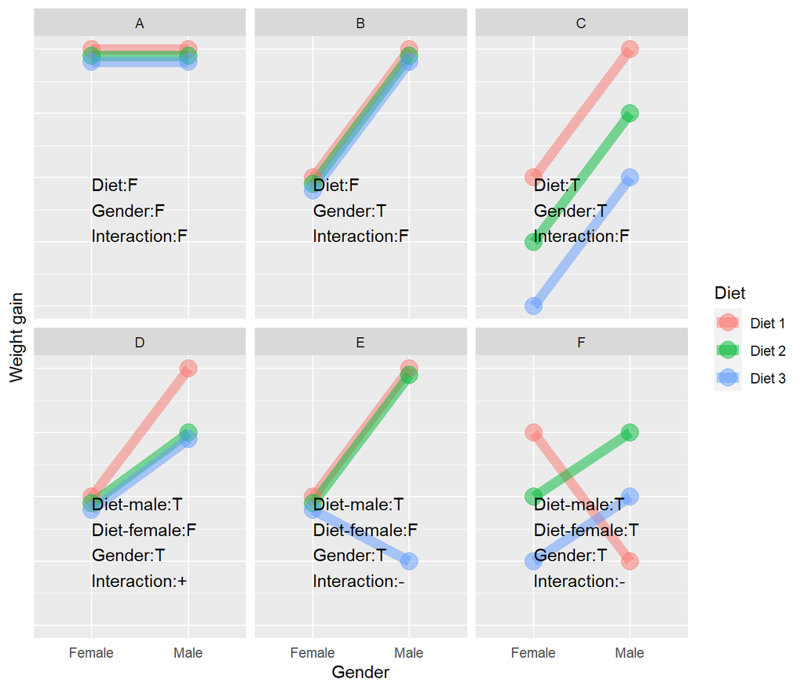

The concept of interaction

```r
aov_wg <- aov(w ~ diet * gender, data = dtf)
summary(aov_wg)
```

[output not shown]

Conclusion:

# 6 Reporting ANOVA

Include the following:

- the degrees of freedom (between groups, within groups) in parentheses
- the *F* value (also referred to as the *F* statistic)
- the *p* value

Examples

- A one-way ANOVA demonstrated that the effect of leadership style was significant for employee engagement, *F*(2, 78) = 4.58, *p* = 0.013.
- We found a statistically significant main effect of age group on social media use, *F*(3, 117) = 3.19, *p* = 0.026.

# 7 Readings

- [One-Way ANOVA](https://brownmath.com/stat/anova1.htm)